# Models of vegetation composition based on climate predictors

Based on code from Martin Holdrege’s Sagebrush-Fire paper

Alice Stears

2024-08-02

The data consists of vegetation % cover by functional group from across CONUS (from AIM, FIA, LANDFIRE, and RAP), as well as climate variables from DayMet, which have been aggregated into mean interannual conditions accross multiple temporal windows.

# Dependencies

User defined parameters

```r
print(params)
```

```
## $test_run
## [1] FALSE
##
## $save_figs
## [1] FALSE
##
## $response
## [1] "ShrubCover_dec"
##
## $hmod
## [1] FALSE
##
## $s
## [1] "ShrubGramCover"
##
## $sample_group
## [1] 1
##
## $byRegion
## [1] TRUE
```

```r
# set to true if want to run for a limited number of rows (i.e. for code testing)
test_run <- params$test_run
save_figs <- params$save_figs
hmod <- params$hmod # whether to include human modification in the model
# by changing the sample_group the model can be fit to a completely different set of rows
sample_group <- params$sample_group
response <- params$response
# _ann defines this model as being built on annual data
s <- params$s # string to paste to file names e.g., that defines the interactions in the model
# such as (summer ppt * MAT) and annuals*temperature interactions
fit_sample <- TRUE # fit model to a sample of the data
n_train <- 5e4 # sample size of the training data
n_test <- 1e6 # sample size of the testing data (if this is too big the decile dotplot code throws memory errors)
byRegion <- params$byRegion
```

```r
# set option so resampled dataset created here reproduces earlier runs of this code with dplyr 1.0.10
source("../../../Functions/glmTransformsIterates.R")
source("../../../Functions/transformPreds.R")
source("../../../Functions/StepBeta_mine.R")
#source("src/fig_params.R")
#source("src/modeling_functions.R")

library(terra)
library(tidyterra)
library(sf)
library(caret)
library(betareg)
library(tidyverse)
library(GGally) # for ggpairs()
library(pdp) # for partial dependence plots
library(gridExtra)
library(knitr)
library(patchwork) # for figure insets etc.
library(ggtext)
library(StepBeta)
theme_set(theme_classic())
```

# read in data

Data compiled in the `prepDataForModels.R` script

```r
modDat <- readRDS("../../../data/DataForModels_withSubEcoreg.rds")
```

# Prep data

```r
set.seed(1234)
modDat_1 <- modDat %>%
  mutate(Lon = st_coordinates(.)[,1],
         Lat = st_coordinates(.)[,2])  %>%
  st_drop_geometry() %>%
  filter(!is.na(newRegion))

# small dataset for if testing the data
if(test_run) {
  modDat_1 <- slice_sample(modDat_1, n = 1e5)
}
```

For now, not doing any resampling

```r
set.seed(1234)

pred_vars <- c("swe_meanAnnAvg_30yr", "tmean_meanAnnAvg_30yr", "prcp_meanAnnTotal_30yr", "PrecipTempCorr_meanAnnAvg_30yr", "isothermality_meanAnnAvg_30yr", "annWetDegDays_meanAnnAvg_30yr")
# removed VPD, since it's highly correlated w/ tmean and prcp

names(pred_vars) <- pred_vars

# predictor vars are the same in both dfs

## remove rows for data that have NAs in the predictors (lag starts before range of DayMet data)

modDat_1 <- modDat_1 %>%
  drop_na(swe_meanAnnAvg_30yr, tmean_meanAnnAvg_30yr, prcp_meanAnnTotal_30yr,
          precip_Seasonality_meanAnnAvg_30yr, PrecipTempCorr_meanAnnAvg_30yr,
          isothermality_meanAnnAvg_30yr, all_of(response))


df_pred <- modDat_1[, pred_vars]
```

Break the data into three groups for model fitting based on lumped ecoregions

```r
if (byRegion == TRUE) {
  modDat_westForest <- modDat_1 %>%
  filter(newRegion == "westForest")

  modDat_eastForest <- modDat_1 %>%
  filter(newRegion == "eastForest")

  modDat_shrubGrass <- modDat_1 %>%
  filter(newRegion == "dryShrubGrass")
}
```

Training data

```r
if (byRegion == TRUE) {
  ## for western forests
  wf_sample <- if(fit_sample & !test_run) {
  reordered <- slice_sample(modDat_westForest, prop = 1)

  low <- (sample_group - 1)*n_train + 1 # first row (of reordered data) to get
  high <- low + n_train - 1 # last row
  if(high > nrow(modDat_westForest)) {
    warning(paste0("n_train size due to low sample size (i.e. < ", n_train,")"))
    n_train <- n_train*.8
     low <- (sample_group - 1)*n_train + 1 # first row (of reordered data) to get
  high <- low + n_train - 1 # last row
   #stop('trying to sample from rows that dont exist')
  }
  reordered[low:high, ]
} else {
    modDat_westForest
}

wf_test <- if(fit_sample & !test_run &
              # antijoin only works if there are enough rows that meet
              # that criterion, i.e. if wf_sample contains most of the data i
              # doesnt' work
              (nrow(modDat_westForest) - nrow(wf_sample) > n_test)) {
  modDat_westForest %>%
    anti_join(wf_sample, by = c("cell_num", "year")) %>%
    slice_sample(n = n_test)
} else {
  modDat_westForest %>%
    slice_sample(n = n_test)
}

# small sample for certain plots
wf_small <- slice_sample(modDat_westForest, n = 1e5)

# for eastern forests
ef_sample <- if(fit_sample & !test_run) {
  reordered <- slice_sample(modDat_eastForest, prop = 1)

  low <- (sample_group - 1)*n_train + 1 # first row (of reordered data) to get
  high <- low + n_train - 1 # last row
  if(high > nrow(modDat_eastForest)) {
    warning(paste0("n_train size due to low sample size (i.e. < ", n_train,")"))
    n_train <- n_train*.8
     low <- (sample_group - 1)*n_train + 1 # first row (of reordered data) to get
  high <- low + n_train - 1 # last row
   #stop('trying to sample from rows that dont exist')
  }
  reordered[low:high, ]
} else {
    modDat_eastForest
}

ef_test <- if(fit_sample & !test_run &
              # antijoin only works if there are enough rows that meet
              # that criterion, i.e. if ef_sample contains most of the data i
              # doesnt' work
              (nrow(modDat_eastForest) - nrow(ef_sample) > n_test)) {
  modDat_eastForest %>%
    anti_join(ef_sample, by = c("cell_num", "year")) %>%
    slice_sample(n = n_test)
} else {
  modDat_eastForest %>%
    slice_sample(n = n_test)
}

# small sample for certain plots
ef_small <- slice_sample(modDat_eastForest, n = 1e5)

## for grass/shrubs
g_sample <- if(fit_sample & !test_run) {
  reordered <- slice_sample(modDat_shrubGrass, prop = 1)

  low <- (sample_group - 1)*n_train + 1 # first row (of reordered data) to get
  high <- low + n_train - 1 # last row
  if(high > nrow(modDat_shrubGrass)) {
    warning(paste0("n_train size due to low sample size (i.e. < ", n_train,")"))
    n_train <- n_train*.8
     low <- (sample_group - 1)*n_train + 1 # first row (of reordered data) to get
  high <- low + n_train - 1 # last row
   #stop('trying to sample from rows that dont exist')
  }
  reordered[low:high, ]
} else {
    modDat_shrubGrass
}

g_test <- if(fit_sample & !test_run &
              # antijoin only works if there are enough rows that meet
              # that criterion, i.e. if g_sample contains most of the data i
              # doesnt' work
              (nrow(modDat_shrubGrass) - nrow(g_sample) > n_test)) {
  modDat_shrubGrass %>%
    anti_join(g_sample, by = c("cell_num", "year")) %>%
    slice_sample(n = n_test)
} else {
  modDat_shrubGrass %>%
    slice_sample(n = n_test)
}

# small sample for certain plots
g_small <- slice_sample(modDat_shrubGrass, n = 1e5)

## do full dataset as well
df_sample <- if(fit_sample & !test_run) {
  reordered <- slice_sample(modDat_1, prop = 1)

  low <- (sample_group - 1)*n_train + 1 # first row (of reordered data) to get
  high <- low + n_train - 1 # last row
  if(high > nrow(modDat_1)) {
    warning(paste0("n_train size due to low sample size (i.e. < ", n_train,")"))
    n_train <- n_train*.8
     low <- (sample_group - 1)*n_train + 1 # first row (of reordered data) to get
  high <- low + n_train - 1 # last row
   #stop('trying to sample from rows that dont exist')
  }
  reordered[low:high, ]
} else {
    modDat_1
}

df_test <- if(fit_sample & !test_run &
              # antijoin only works if there are enough rows that meet
              # that criterion, i.e. if df_sample contains most of the data i
              # doesnt' work
              (nrow(modDat_1) - nrow(df_sample) > n_test)) {
  modDat_1 %>%
    anti_join(df_sample, by = c("cell_num", "year")) %>%
    slice_sample(n = n_test)
} else {
  modDat_1 %>%
    slice_sample(n = n_test)
}

# small sample for certain plots
df_small <- slice_sample(modDat_1, n = 1e5)

} else  if (byRegion == FALSE) {

  df_sample <- if(fit_sample & !test_run) {
  reordered <- slice_sample(modDat_1, prop = 1)

  low <- (sample_group - 1)*n_train + 1 # first row (of reordered data) to get
  high <- low + n_train - 1 # last row
  if(high > nrow(modDat_1)) {
    warning(paste0("n_train size due to low sample size (i.e. < ", n_train,")"))
    n_train <- n_train*.8
     low <- (sample_group - 1)*n_train + 1 # first row (of reordered data) to get
  high <- low + n_train - 1 # last row
   #stop('trying to sample from rows that dont exist')
  }
  reordered[low:high, ]
} else {
    modDat_1
}

df_test <- if(fit_sample & !test_run &
              # antijoin only works if there are enough rows that meet
              # that criterion, i.e. if df_sample contains most of the data i
              # doesnt' work
              (nrow(modDat_1) - nrow(df_sample) > n_test)) {
  modDat_1 %>%
    anti_join(df_sample, by = c("cell_num", "year")) %>%
    slice_sample(n = n_test)
} else {
  modDat_1 %>%
    slice_sample(n = n_test)
}

# small sample for certain plots
df_small <- slice_sample(modDat_1, n = 1e5)
}
```

# Exploratory figs & summary values

```r
create_summary <- function(df) {
  df %>%
    pivot_longer(cols = everything(),
                 names_to = 'variable') %>%
    group_by(variable) %>%
    summarise(across(value, .fns = list(mean = ~mean(.x, na.rm = TRUE), min = ~min(.x, na.rm = TRUE),
                                        median = ~median(.x, na.rm = TRUE), max = ~max(.x, na.rm = TRUE)))) %>%
    mutate(across(where(is.numeric), round, 4))
}

modDat_1[pred_vars] %>%
  create_summary() %>%
  knitr::kable(caption = 'summaries of predictor variables')
```

summaries of predictor variables

| variable | value_mean | value_min | value_median | value_max |
| --- | --- | --- | --- | --- |
| PrecipTempCorr_meanAnnAvg_30yr | -0.1343 | -0.8556 | -0.1222 | 0.7145 |
| annWetDegDays_meanAnnAvg_30yr | 1656.9821 | 208.9903 | 1658.6605 | 2713.2516 |
| isothermality_meanAnnAvg_30yr | -37.1425 | -61.3018 | -36.8681 | -20.2171 |
| prcp_meanAnnTotal_30yr | 759.3312 | 52.1693 | 537.1743 | 4116.7860 |
| swe_meanAnnAvg_30yr | 16.2436 | 0.0000 | 2.7806 | 1471.5825 |
| tmean_meanAnnAvg_30yr | 6.8053 | 1.7479 | 6.8608 | 10.3473 |

```r
response_summary <- modDat_1 %>%
    dplyr::select(#where(is.numeric), -all_of(pred_vars),
      matches(response)) %>%
    create_summary()


kable(response_summary,
      caption = 'summaries of response variables, calculated using paint')
```

summaries of response variables, calculated using paint

| variable | value_mean | value_min | value_median | value_max |
| --- | --- | --- | --- | --- |
| ShrubCover_dec | 0.1313 | 1e-04 | 0.075 | 0.999 |

## Plot predictor vars against each other

here using pred dataframe, because smaller and this code is slow.

```r
df_pred %>%
  slice_sample(n = 5e4) %>%
  #select(-matches("_")) %>%
ggpairs(lower = list(continuous = GGally::wrap("points", alpha = 0.1, size=0.2)),
        columnLabels = c("swe", "tmean", "prcp", "prcpTempCorr", "isothermality", "wetDegDays"))
```

[figure not shown]

## boxplots– # predictor variables compared to binned response variables

```r
# vectors of names of response variables
vars_response <- response

# longformat dataframes for making boxplots
if (byRegion == FALSE) {
df_sample_plots <-  df_sample %>%
  rename(response = all_of(response)) %>%
  mutate(response = case_when(
    response <= .25 ~ ".25",
    response > .25 & response <=.5 ~ ".5",
    response > .5 & response <=.75 ~ ".75",
    response >= .75  ~ "1",
  )) %>%
  select(c(response, pred_vars)) %>%
  pivot_longer(cols = names(pred_vars),
               names_to = "predictor",
               values_to = "value") %>%
  filter(!is.na(response) & !is.na(value))
} else {
  df_sample_plots <-  df_sample %>%
  select(c(response, pred_vars, newRegion))  %>%
  rename(response = all_of(response),
         swe = swe_meanAnnAvg_30yr,
         MAT = tmean_meanAnnAvg_30yr,
         MAP = prcp_meanAnnTotal_30yr,
         PrecipTempCorr = PrecipTempCorr_meanAnnAvg_30yr,
         isothermality = isothermality_meanAnnAvg_30yr,
         wetDegDays = annWetDegDays_meanAnnAvg_30yr
         ) %>%
  mutate(response = case_when(
    response <= .25 ~ ".25",
    response > .25 & response <=.5 ~ ".5",
    response > .5 & response <=.75 ~ ".75",
    response >= .75  ~ "1",
  ))  %>%
  pivot_longer(cols = c(swe, MAT, MAP, PrecipTempCorr, isothermality, wetDegDays),
               names_to = "predictor",
               values_to = "value") %>%
  filter(!is.na(response) & !is.na(value))
}

# df_biome_long <-
#   # for some reason select() was giving me problems
#   # adding numYrs here so can take weighted average
#   predvars2long(modDat_1, response_vars = c(vars_response),
#                 pred_vars = pred_vars) #%>%
#    # mutate(across(all_of(vars_nfire), factor))


if (byRegion == FALSE) {
  ggplot(df_sample_plots, aes_string(x= "response", y = 'value')) +
  geom_boxplot() +
  facet_wrap(~predictor, scales = 'free_y') +
  ylab("Predictor Variable Values")
} else {
  ggplot(df_sample_plots, aes_string(x= "response", y = 'value')) +
  geom_boxplot() +
  facet_wrap(~predictor + newRegion , scales = 'free_y') +
  ylab("Predictor Variable Values")
}
```

[figure not shown]

# GLMs

## fitting models

### fitting various transforms

Creating formulas where each variable on its own is transformed numerous ways (including formula to fit spline), all other variables are left alone, that repeated for each variable. So have models with 1 variable transformed, 2 transformed, etc.

see documentation for glms_iterate_transforms, in the modelling_functions.R script

```r
set.seed(1234)

# adding an interaction term to help deal with over-predicting fire probability
# at pixels with high afgAGB and high MAP. parentheses around interaction
# term are included so that glms_iterate_transforms doesn't transform
# the interaction term.
#pred_vars_inter <- c(pred_vars, params$inter)


# pred_vars_inter <- pred_vars
mods_glm_transf_temp <- glmTransformsIterates(
  preds = pred_vars,
  df = df_sample,
  response_var = response,
  delta_aic = 10)
```

```
## [1] "step1"
##
##  -140563.2
## -142089.6
## delta aic cutoff 10
## [1] "step2"
##
##  -142089.6
## -142887.5
## delta aic cutoff 10
## [1] "step3"
##
##  -142887.5
## -143222.7
## delta aic cutoff 10
## [1] "step4"
##
##  -143222.7
## -143326.4
## delta aic cutoff 10
## [1] "step5"
##
##  -143326.4
## -143333.9
## delta aic cutoff 10
```

```r
# not including the last element of the list which is final_formula
mods_glm_transf <- mods_glm_transf_temp[-length(mods_glm_transf_temp)]

map_dfc(mods_glm_transf, ~ names(.$aic[1:5])) %>%
  kable(caption = "5 best transformations at each step")
```

5 best transformations at each step

| step1 | step2 | step3 | step4 | step5 |
| --- | --- | --- | --- | --- |
| convert_poly2log10_swe_meanAnnAvg_30yr | convert_poly2_prcp_meanAnnTotal_30yr | convert_poly2log10_PrecipTempCorr_meanAnnAvg_30yr | convert_poly2_isothermality_meanAnnAvg_30yr | convert_poly2_tmean_meanAnnAvg_30yr |
| convert_poly2sqrt_swe_meanAnnAvg_30yr | convert_poly2sqrt_prcp_meanAnnTotal_30yr | convert_log10_PrecipTempCorr_meanAnnAvg_30yr | convert_poly2log10_annWetDegDays_meanAnnAvg_30yr | convert_log10_tmean_meanAnnAvg_30yr |
| convert_poly2_prcp_meanAnnTotal_30yr | convert_poly2log10_prcp_meanAnnTotal_30yr | convert_poly2_PrecipTempCorr_meanAnnAvg_30yr | convert_log10_tmean_meanAnnAvg_30yr | convert_poly2sqrt_tmean_meanAnnAvg_30yr |
| convert_log10_swe_meanAnnAvg_30yr | convert_log10_prcp_meanAnnTotal_30yr | convert_poly2_annWetDegDays_meanAnnAvg_30yr | convert_poly2_tmean_meanAnnAvg_30yr | convert_poly2log10_tmean_meanAnnAvg_30yr |
| convert_poly2log10_PrecipTempCorr_meanAnnAvg_30yr | convert_poly2log10_PrecipTempCorr_meanAnnAvg_30yr | convert_poly2sqrt_annWetDegDays_meanAnnAvg_30yr | convert_poly2sqrt_tmean_meanAnnAvg_30yr | convert_sqrt_tmean_meanAnnAvg_30yr |

```r
best_aic_by_step <- map_dbl(mods_glm_transf, ~.$aic[1])

best_aic_by_step <- c(step0 = mods_glm_transf_temp$step1$aic[['convert_none']],
                      best_aic_by_step)
# AIC improvement by step
diff(best_aic_by_step)
```

```
##        step1        step2        step3        step4        step5
## -1526.455135  -797.870995  -335.217519  -103.673226    -7.476664
```

```r
plot(y = best_aic_by_step,
     x = 1:length(best_aic_by_step) - 1,
     ylab = "AIC",
     xlab = "Number of variables transformed")
```

[figure not shown]

```r
if (byRegion == TRUE) {
  ## for western forests
  mods_glm_transf_WF_temp <- glmTransformsIterates(
  preds = pred_vars,
  df = wf_sample,
  response_var = response,
  delta_aic = 10)

# not including the last element of the list which is final_formula
mods_glm_transf_WF <- mods_glm_transf_WF_temp[-length(mods_glm_transf_WF_temp)]

map_dfc(mods_glm_transf_WF, ~ names(.$aic[1:5])) %>%
  kable(caption = "5 best transformations at each step")
best_aic_by_step_WF <- map_dbl(mods_glm_transf_WF, ~.$aic[1])

best_aic_by_step_WF <- c(step0 = mods_glm_transf_WF_temp$step1$aic[['convert_none']],
                      best_aic_by_step_WF)
# AIC improvement by step
diff(best_aic_by_step_WF)
plot(y = best_aic_by_step_WF,
     x = 1:length(best_aic_by_step_WF) - 1,
     ylab = "AIC",
     xlab = "Number of variables transformed")

## for eastern forests
  mods_glm_transf_EF_temp <- glmTransformsIterates(
  preds = pred_vars,
  df = ef_sample,
  response_var = response,
  delta_aic = 10)

# not including the last element of the list which is final_formula
mods_glm_transf_EF <- mods_glm_transf_EF_temp[-length(mods_glm_transf_EF_temp)]

map_dfc(mods_glm_transf_EF, ~ names(.$aic[1:5])) %>%
  kable(caption = "5 best transformations at each step")
best_aic_by_step_EF <- map_dbl(mods_glm_transf_EF, ~.$aic[1])

best_aic_by_step_EF <- c(step0 = mods_glm_transf_EF_temp$step1$aic[['convert_none']],
                      best_aic_by_step_EF)
# AIC improvement by step
diff(best_aic_by_step_EF)
plot(y = best_aic_by_step_EF,
     x = 1:length(best_aic_by_step_EF) - 1,
     ylab = "AIC",
     xlab = "Number of variables transformed")

## for grasslands/shrubs
  mods_glm_transf_G_temp <- glmTransformsIterates(
  preds = pred_vars,
  df = g_sample,
  response_var = response,
  delta_aic = 10)

# not including the last element of the list which is final_formula
mods_glm_transf_G <- mods_glm_transf_G_temp[-length(mods_glm_transf_G_temp)]

map_dfc(mods_glm_transf_G, ~ names(.$aic[1:5])) %>%
  kable(caption = "5 best transformations at each step")
best_aic_by_step_G <- map_dbl(mods_glm_transf_G, ~.$aic[1])

best_aic_by_step_G <- c(step0 = mods_glm_transf_G_temp$step1$aic[['convert_none']],
                      best_aic_by_step_G)
# AIC improvement by step
diff(best_aic_by_step_G)
plot(y = best_aic_by_step_G,
     x = 1:length(best_aic_by_step_G) - 1,
     ylab = "AIC",
     xlab = "Number of variables transformed")
}
```

```
## [1] "step1"
##
##  -83371.72
## -83649.73
## delta aic cutoff 10
## [1] "step2"
##
##  -83649.73
## -83716.96
## delta aic cutoff 10
## [1] "step3"
##
##  -83716.96
## -83775.94
## delta aic cutoff 10
## [1] "step4"
##
##  -83775.94
## -83790.41
## delta aic cutoff 10
## [1] "step5"
##
##  -83790.41
## -83797.27
## delta aic cutoff 10
```

[figure not shown]

```
## [1] "step1"
##
##  -283262.5
## -283540.6
## delta aic cutoff 10
## [1] "step2"
##
##  -283540.6
## -283667.8
## delta aic cutoff 10
## [1] "step3"
##
##  -283667.8
## -283702.7
## delta aic cutoff 10
## [1] "step4"
##
##  -283702.7
## -283722
## delta aic cutoff 10
## [1] "step5"
##
##  -283722
## -283723.5
## delta aic cutoff 10
```

[figure not shown]

```
## [1] "step1"
##
##  -125036.5
## -126835.5
## delta aic cutoff 10
## [1] "step2"
##
##  -126835.5
## -127885
## delta aic cutoff 10
## [1] "step3"
## Error in chol.default(K) : the leading minor of order 11 is not positive
## Error in chol.default(K) : the leading minor of order 11 is not positive
## Error in chol.default(K) : the leading minor of order 11 is not positive
##
##  -127885
## -128570.2
## delta aic cutoff 10
## [1] "step4"
## Error in chol.default(K) : the leading minor of order 12 is not positive
## Error in chol.default(K) : the leading minor of order 12 is not positive
##
##  -128570.2
## -129054.7
## delta aic cutoff 10
## [1] "step5"
## Error in chol.default(K) : the leading minor of order 2 is not positive
## Error in chol.default(K) : the leading minor of order 13 is not positive
##
##  -129054.7
## -129173
## delta aic cutoff 10
## [1] "step6"
## Error in chol.default(K) : the leading minor of order 2 is not positive
## Error in chol.default(K) : the leading minor of order 14 is not positive
##
##  -129173
## -129237.7
## delta aic cutoff 10
```

[figure not shown]

Best transformation each step.

```r
bestTransformed <- mods_glm_transf_temp$final_formula
if (byRegion == TRUE) {
  # for western forests
  #var_transformed_WF <- map(mods_glm_transf_WF, function(x) x$var_transformed)
bestTransformed_WF <- mods_glm_transf_WF_temp$final_formula

# for eastern forests
#var_transformed_EF <- map(mods_glm_transf_EF, function(x) x$var_transformed)
bestTransformed_EF <- mods_glm_transf_EF_temp$final_formula

# for grass/shrub
#var_transformed_G <- map(mods_glm_transf_G, function(x) x$var_transformed)
bestTransformed_G <- mods_glm_transf_G_temp$final_formula
}
```

### adding interaction terms

Plot potential interaction terms using raw data

across values of swe

```r
# calculate quantiles
swe_quants <- quantile(df_sample$swe_meanAnnAvg_30yr, na.rm = TRUE)
# longformat dataframe for making boxplots
df_sample_swe <-  df_sample %>%
  select(c(response, pred_vars)) %>%
  # transform the predictors according to above process
  mutate(isotherm = as.numeric(stats::poly(isothermality_meanAnnAvg_30yr,2,raw=TRUE)[,1]),

          wetDegDays= as.numeric(stats::poly(annWetDegDays_meanAnnAvg_30yr,2,raw=TRUE)[,1]),
         swe_log = as.numeric(stats::poly(I(log10(I(swe_meanAnnAvg_30yr+1))),2,raw=TRUE)[,1]),
        #swe_log_squared = as.numeric(stats::poly(I(log10(I(swe_meanAnnAvg_30yr+1))),2,raw=TRUE)[,2]),
         tmean_log =            as.numeric(stats::poly(I(log10(I(tmean_meanAnnAvg_30yr+1))),2,raw=TRUE)[,1] ),
         #tmean_log_squared =    as.numeric(stats::poly(I(log10(I(tmean_meanAnnAvg_30yr+1))),2,raw=TRUE)[,2] ),
         prcp_log =             as.numeric(stats::poly(I(log10(I(prcp_meanAnnTotal_30yr+1))),2,raw=TRUE)[,1]),
        # prcp_log_squared =     as.numeric(stats::poly(I(log10(I(prcp_meanAnnTotal_30yr+1))),2,raw=TRUE)[,2]),
         prcpTempCorr = as.numeric(stats::poly(PrecipTempCorr_meanAnnAvg_30yr,2,raw=TRUE)[,1])
         ) %>%
  rename(response = all_of(response)) %>%
  # mutate(response = case_when(
  #   response <= .25 ~ ".25",
  #   response > .25 & response <=.5 ~ ".5",
  #   response > .5 & response <=.75 ~ ".75",
  #   response >= .75  ~ "1",
  # )) %>%
  # pivot_longer(cols = 2:16,
  #              names_to = "predictor",
  #              values_to = "value") %>%
  # filter(!is.na(response) & !is.na(value))
  mutate(swe_meanAnnAvg_30yr_quants = case_when(
    swe_meanAnnAvg_30yr <= swe_quants[2] ~ swe_quants[2],
    swe_meanAnnAvg_30yr > swe_quants[2]  & swe_meanAnnAvg_30yr <= swe_quants[3]  ~ swe_quants[3],
    swe_meanAnnAvg_30yr > swe_quants[3]  & swe_meanAnnAvg_30yr <= swe_quants[4]  ~ swe_quants[4],
    swe_meanAnnAvg_30yr >= swe_quants[4]  ~ swe_quants[5],
  )) %>%
  pivot_longer(cols = 2:13,
               names_to = "predictor",
               values_to = "value") %>%
  filter(!is.na(response) & !is.na(value))

# plot relationships amongst variables according to different levels of SWE
ggplot(data = df_sample_swe[!(df_sample_swe$predictor %in% c("swe_log","swe_meanAnnAvg_30yr")),]) +
  #geom_point(aes(y = response, x = value, col = as.factor(swe_meanAnnAvg_30yr_quants)), alpha = .5) +
  geom_smooth(aes(y = response, x = value,  col = as.factor(swe_meanAnnAvg_30yr_quants)), method = "gam") +
  facet_wrap(~predictor, scales = "free_x")
```

[figure not shown]

Mean Annual Temperature

```r
tmean_quants <- quantile(df_sample$tmean_meanAnnAvg_30yr, na.rm = TRUE)

# longformat dataframe for making boxplots
df_sample_tmean <-  df_sample %>%
  select(c(response, pred_vars)) %>%
  # transform the predictors according to above process
  mutate(isotherm = as.numeric(stats::poly(isothermality_meanAnnAvg_30yr,2,raw=TRUE)[,1]),

          wetDegDays= as.numeric(stats::poly(annWetDegDays_meanAnnAvg_30yr,2,raw=TRUE)[,1]),
         swe_log = as.numeric(stats::poly(I(log10(I(swe_meanAnnAvg_30yr+1))),2,raw=TRUE)[,1]),
        #swe_log_squared = as.numeric(stats::poly(I(log10(I(swe_meanAnnAvg_30yr+1))),2,raw=TRUE)[,2]),
         tmean_log =            as.numeric(stats::poly(I(log10(I(tmean_meanAnnAvg_30yr+1))),2,raw=TRUE)[,1] ),
         #tmean_log_squared =    as.numeric(stats::poly(I(log10(I(tmean_meanAnnAvg_30yr+1))),2,raw=TRUE)[,2] ),
         prcp_log =             as.numeric(stats::poly(I(log10(I(prcp_meanAnnTotal_30yr+1))),2,raw=TRUE)[,1]),
        # prcp_log_squared =     as.numeric(stats::poly(I(log10(I(prcp_meanAnnTotal_30yr+1))),2,raw=TRUE)[,2]),
         prcpTempCorr = as.numeric(stats::poly(PrecipTempCorr_meanAnnAvg_30yr,2,raw=TRUE)[,1])
         ) %>%
  rename(response = all_of(response)) %>%
  # mutate(response = case_when(
  #   response <= .25 ~ ".25",
  #   response > .25 & response <=.5 ~ ".5",
  #   response > .5 & response <=.75 ~ ".75",
  #   response >= .75  ~ "1",
  # )) %>%
  # pivot_longer(cols = 2:16,
  #              names_to = "predictor",
  #              values_to = "value") %>%
  # filter(!is.na(response) & !is.na(value))
  mutate(tmean_meanAnnAvg_30yr_quants = case_when(
    tmean_meanAnnAvg_30yr <= tmean_quants[2] ~ tmean_quants[2],
    tmean_meanAnnAvg_30yr > tmean_quants[2]  & tmean_meanAnnAvg_30yr <= tmean_quants[3]  ~ tmean_quants[3],
    tmean_meanAnnAvg_30yr > tmean_quants[3]  & tmean_meanAnnAvg_30yr <= tmean_quants[4]  ~ tmean_quants[4],
    tmean_meanAnnAvg_30yr >= tmean_quants[4]  ~ tmean_quants[5],
  )) %>%
  pivot_longer(cols = 2:13,
               names_to = "predictor",
               values_to = "value") %>%
  filter(!is.na(response) & !is.na(value))

# plot relationships amongst variables according to different levels of tmean
ggplot(data = df_sample_tmean[!(df_sample_tmean$predictor %in% c("tmean_log", "tmean_meanAnnAvg_30yr")),]) +
  #geom_point(aes(y = response, x = value, col = as.factor(tmean_meanAnnAvg_30yr_quants)), alpha = .3) +
  geom_smooth(aes(y = response, x = value,  col = as.factor(tmean_meanAnnAvg_30yr_quants)), method = "gam") +
  facet_wrap(~predictor, scales = "free_x")
```

[figure not shown]

Mean annual precipitation

```r
prcp_quants <- quantile(df_sample$prcp_meanAnnTotal_30yr, na.rm = TRUE)

# longformat dataframe for making boxplots
df_sample_prcp <-  df_sample %>%
  select(c(response, pred_vars)) %>%
  # transform the predictors according to above process
  mutate(isotherm = as.numeric(stats::poly(isothermality_meanAnnAvg_30yr,2,raw=TRUE)[,1]),

          wetDegDays= as.numeric(stats::poly(annWetDegDays_meanAnnAvg_30yr,2,raw=TRUE)[,1]),
         swe_log = as.numeric(stats::poly(I(log10(I(swe_meanAnnAvg_30yr+1))),2,raw=TRUE)[,1]),
        #swe_log_squared = as.numeric(stats::poly(I(log10(I(swe_meanAnnAvg_30yr+1))),2,raw=TRUE)[,2]),
         tmean_log =            as.numeric(stats::poly(I(log10(I(tmean_meanAnnAvg_30yr+1))),2,raw=TRUE)[,1] ),
         #tmean_log_squared =    as.numeric(stats::poly(I(log10(I(tmean_meanAnnAvg_30yr+1))),2,raw=TRUE)[,2] ),
         prcp_log =             as.numeric(stats::poly(I(log10(I(prcp_meanAnnTotal_30yr+1))),2,raw=TRUE)[,1]),
        # prcp_log_squared =     as.numeric(stats::poly(I(log10(I(prcp_meanAnnTotal_30yr+1))),2,raw=TRUE)[,2]),
         prcpTempCorr = as.numeric(stats::poly(PrecipTempCorr_meanAnnAvg_30yr,2,raw=TRUE)[,1])
         ) %>%
  rename(response = all_of(response)) %>%
  # mutate(response = case_when(
  #   response <= .25 ~ ".25",
  #   response > .25 & response <=.5 ~ ".5",
  #   response > .5 & response <=.75 ~ ".75",
  #   response >= .75  ~ "1",
  # )) %>%
  # pivot_longer(cols = 2:16,
  #              names_to = "predictor",
  #              values_to = "value") %>%
  # filter(!is.na(response) & !is.na(value))
  mutate(prcp_meanAnnTotal_30yr_quants = case_when(
    prcp_meanAnnTotal_30yr <= prcp_quants[2] ~ prcp_quants[2],
    prcp_meanAnnTotal_30yr > prcp_quants[2]  & prcp_meanAnnTotal_30yr <= prcp_quants[3]  ~ prcp_quants[3],
    prcp_meanAnnTotal_30yr > prcp_quants[3]  & prcp_meanAnnTotal_30yr <= prcp_quants[4]  ~ prcp_quants[4],
    prcp_meanAnnTotal_30yr >= prcp_quants[4]  ~ prcp_quants[5],
  )) %>%
  pivot_longer(cols = 2:13,
               names_to = "predictor",
               values_to = "value") %>%
  filter(!is.na(response) & !is.na(value))

# plot relationships amongst variables according to different levels of tmean
ggplot(data = df_sample_prcp[!(df_sample_prcp$predictor %in% c("prcp_log", "prcp_meanAnnTotal_30yr")),]) +
  #geom_point(aes(y = response, x = value, col = as.factor(prcp_meanAnnTotal_30yr_quants)), alpha = .3) +
  geom_smooth(aes(y = response, x = value,  col = as.factor(prcp_meanAnnTotal_30yr_quants)), method = "gam") +
  facet_wrap(~predictor, scales = "free_x")
```

[figure not shown]

#### we’ll try running the model w/ all possible interactions

```r
  ## make table of possible interactions
# make list of transformed variables into a data.frame
var_transformed_df <- as.data.frame(str_remove(bestTransformed, paste0(response, " ~ ")) %>%
  str_split(pattern = fixed(" + "), simplify = TRUE))#purrr::flatten_dfr(var_transformed_WF) #%>%


# if has a "stats::poly( to start, remove that part
temp <- apply(var_transformed_df, MARGIN = 2, FUN = function(x) {
if(str_detect(x, pattern = fixed("stats::poly("))) {
  x_new <- str_remove(x, pattern = fixed("stats::poly(")) %>%
    str_remove_all(pattern = " ") %>%
  str_remove(pattern = fixed(",2,raw=TRUE)"))
} else {
  x_new <- x
}
})

# combine into the 32 possible interactions
combos <- data.frame(gtools::permutations(n = length(temp),
r = 2,
v = temp))

combos$interactions <- paste0(combos$X1, ":", combos$X2)
# make text string of interactions
int_string <-str_flatten(combos$interactions, collapse = " + ")
# formula w/ interactions included
modWithInteractions <- paste(bestTransformed, "+",int_string) %>%
str_remove_all(fixed("stats::"))
# refitting the glm with the best formula
mod_glm1 <- betareg(as.formula(modWithInteractions), data = df_sample, link = c("logit"), link.phi = NULL,
 type = c("ML"))


if (byRegion == TRUE) {
  # western forests
   ## make table of possible interactions
# make list of transformed variables into a data.frame
var_transformed_df_WF <- as.data.frame(str_remove(bestTransformed_WF, paste0(response, " ~ ")) %>%
  str_split(pattern = fixed(" + "), simplify = TRUE))#purrr::flatten_dfr(var_transformed_WF) #%>%

# if has a "stats::poly( to start, remove that part
temp_WF <- apply(var_transformed_df_WF, MARGIN = 2, FUN = function(x) {
if(str_detect(x, pattern = fixed("stats::poly("))) {
  x_new <- str_remove(x, pattern = fixed("stats::poly(")) %>%
    str_remove_all(" ") %>%
  str_remove(pattern = fixed(",2,raw=TRUE)"))
} else {
  x_new <- x
}
})

# combine into the 32 possible interactions
combos_WF <- data.frame(gtools::permutations(n = length(temp_WF),
r = 2,
v = temp_WF))

combos_WF$interactions <- paste0(combos_WF$X1, ":", combos_WF$X2)
# make text string of interactions
int_string_WF <-str_flatten(combos_WF$interactions, collapse = " + ")
# formula w/ interactions included
modWithInteractions_WF <- paste(bestTransformed_WF, "+", int_string_WF) %>% str_remove_all(fixed("stats::"))
# refitting the glm with the best formula
mod_glm1_WF <- betareg(as.formula(modWithInteractions_WF), data = wf_sample, link = c("logit"), link.phi = NULL,
 type = c("ML"))

  # eastern forests
    ## make table of possible interactions
# make list of transformed variables into a data.frame
var_transformed_df_EF <- as.data.frame(str_remove(bestTransformed_EF, paste0(response, " ~ ")) %>%
  str_split(pattern = fixed(" + "), simplify = TRUE))#purrr::flatten_dfr(var_transformed_EF) #%>%

# if has a "stats::poly( to start, remove that part
temp_EF <- apply(var_transformed_df_EF, MARGIN = 2, FUN = function(x) {
if(str_detect(x, pattern = fixed("stats::poly("))) {
  x_new <- str_remove(x, pattern = fixed("stats::poly(")) %>%
    str_remove_all(" ") %>%
  str_remove(pattern = fixed(",2,raw=TRUE)"))
} else {
  x_new <- x
}
})

# combine into the 30 possible interactions
combos_EF <- data.frame(gtools::permutations(n = length(temp_EF),
r = 2,
v = temp_EF))

combos_EF$interactions <- paste0(combos_EF$X1, ":", combos_EF$X2)
# make text string of interactions
int_string_EF <-str_flatten(combos_EF$interactions, collapse = " + ")
# formula w/ interactions included
modWithInteractions_EF <- paste(bestTransformed_EF, "+", int_string_EF) %>% str_remove_all(fixed("stats::"))
# refitting the glm with the best formula
mod_glm1_EF <- betareg(as.formula(modWithInteractions_EF), data = ef_sample, link = c("logit"), link.phi = NULL,
 type = c("ML"))

  ## grassland/shrubs
    ## make table of possible interactions
# make list of transformed variables into a data.frame
var_transformed_df_G <- as.data.frame(str_remove(bestTransformed_G, paste0(response, " ~ ")) %>%
  str_split(pattern = fixed(" + "), simplify = TRUE))#purrr::flatten_dfr(var_transformed_G) #%>%

# if has a "stats::poly( to start, remove that part
temp_G <- apply(var_transformed_df_G, MARGIN = 2, FUN = function(x) {
if(str_detect(x, pattern = fixed("stats::poly("))) {
  x_new <- str_remove(x, pattern = fixed("stats::poly(")) %>%
    str_remove_all(" ") %>%
  str_remove(pattern = fixed(",2,raw=TRUE)"))
} else {
  x_new <- x
}
})

# combine into the 30 possible interactions
combos_G <- data.frame(gtools::permutations(n = length(temp_G),
r = 2,
v = temp_G))

combos_G$interactions <- paste0(combos_G$X1, ":", combos_G$X2)
# make text string of interactions
int_string_G <-str_flatten(combos_G$interactions, collapse = " + ")
# formula w/ interactions included
modWithInteractions_G <- paste(bestTransformed_G, "+", int_string_G) %>% str_remove_all(fixed("stats::"))
# rGitting the glm with the best formula
mod_glm1_G <- betareg(as.formula(modWithInteractions_G), data = g_sample, link = c("logit"), link.phi = NULL,
 type = c("ML"))

}
```

### performing backwards AIC-based model selection

Using the “StepBeta” function from the StepBeta R package

```r
modSelection <- StepBeta_mine(mod_glm1, data = df_sample)
```

```
## [1] "100 % of the process"
```

```r
if (byRegion == TRUE) {
  modSelection_WF <- StepBeta_mine(mod_glm1_WF, data = wf_sample)
  modSelection_EF <- StepBeta_mine(mod_glm1_EF, data = ef_sample)
  modSelection_G <- StepBeta_mine(mod_glm1_G, data = g_sample)
}
```

[output not shown]

### same model for all response variables

```r
 best_form <- modSelection$formula
print(best_form)
```

```
## ShrubCover_dec ~ poly(prcp_meanAnnTotal_30yr, 2, raw = TRUE) +
##     poly(I(log10(I(PrecipTempCorr_meanAnnAvg_30yr + 1))), 2,
##         raw = TRUE) + poly(I(log10(I(swe_meanAnnAvg_30yr + 1))),
##     2, raw = TRUE) + poly(isothermality_meanAnnAvg_30yr, 2, raw = TRUE) +
##     tmean_meanAnnAvg_30yr + annWetDegDays_meanAnnAvg_30yr + I(log10(I(PrecipTempCorr_meanAnnAvg_30yr +
##     1))):prcp_meanAnnTotal_30yr + annWetDegDays_meanAnnAvg_30yr:isothermality_meanAnnAvg_30yr +
##     tmean_meanAnnAvg_30yr:I(log10(I(swe_meanAnnAvg_30yr + 1))) +
##     I(log10(I(swe_meanAnnAvg_30yr + 1))):isothermality_meanAnnAvg_30yr +
##     I(log10(I(PrecipTempCorr_meanAnnAvg_30yr + 1))):I(log10(I(swe_meanAnnAvg_30yr +
##         1))) + isothermality_meanAnnAvg_30yr:prcp_meanAnnTotal_30yr +
##     tmean_meanAnnAvg_30yr:annWetDegDays_meanAnnAvg_30yr + tmean_meanAnnAvg_30yr:prcp_meanAnnTotal_30yr +
##     annWetDegDays_meanAnnAvg_30yr:I(log10(I(PrecipTempCorr_meanAnnAvg_30yr +
##         1))) + tmean_meanAnnAvg_30yr:I(log10(I(PrecipTempCorr_meanAnnAvg_30yr +
##     1))) + I(log10(I(swe_meanAnnAvg_30yr + 1))):prcp_meanAnnTotal_30yr +
##     annWetDegDays_meanAnnAvg_30yr:I(log10(I(swe_meanAnnAvg_30yr +
##         1))) + tmean_meanAnnAvg_30yr:isothermality_meanAnnAvg_30yr
## <environment: 0x41fdde0c8>
```

```r
# refitting the glm with the best formula
mod_glmFinal <- betareg(as.formula(best_form), data = df_sample, link = c("logit"), link.phi = NULL,
                              type = c("ML"))

# should be the same AIC (i.e. refitting the same model)
AIC(mod_glmFinal)
```

```
## [1] -146307.9
```

```r
if (byRegion == TRUE) {
  ## western forests
  best_form_WF <- modSelection_WF$formula
print(best_form_WF)

# refitting the glm with the best formula
mod_glmFinal_WF <- betareg(as.formula(best_form_WF), data = wf_sample, link = c("logit"), link.phi = NULL,
                              type = c("ML"))
# should be the same AIC (i.e. refitting the same model)
AIC(mod_glmFinal_WF)

 ## easter forests
  best_form_EF <- modSelection_EF$formula
print(best_form_EF)

# refitting the glm with the best formula
mod_glmFinal_EF <- betareg(as.formula(best_form_EF), data = ef_sample, link = c("logit"), link.phi = NULL,
                              type = c("ML"))
# should be the same AIC (i.e. refitting the same model)
AIC(mod_glmFinal_EF)

 ## grass/shrub
  best_form_G <- modSelection_G$formula
print(best_form_G)

# refitting the glm with the best formula
mod_glmFinal_G <- betareg(as.formula(best_form_G), data = g_sample, link = c("logit"), link.phi = NULL,
                              type = c("ML"))
# should be the same AIC (i.e. refitting the same model)
AIC(mod_glmFinal_G)
}
```

```
## ShrubCover_dec ~ swe_meanAnnAvg_30yr + poly(isothermality_meanAnnAvg_30yr,
##     2, raw = TRUE) + poly(I(log10(I(prcp_meanAnnTotal_30yr +
##     1))), 2, raw = TRUE) + poly(annWetDegDays_meanAnnAvg_30yr,
##     2, raw = TRUE) + poly(I(log10(I(PrecipTempCorr_meanAnnAvg_30yr +
##     1))), 2, raw = TRUE) + tmean_meanAnnAvg_30yr + I(log10(I(prcp_meanAnnTotal_30yr +
##     1))):I(log10(I(PrecipTempCorr_meanAnnAvg_30yr + 1))) + tmean_meanAnnAvg_30yr:I(log10(I(prcp_meanAnnTotal_30yr +
##     1))) + tmean_meanAnnAvg_30yr:annWetDegDays_meanAnnAvg_30yr +
##     tmean_meanAnnAvg_30yr:I(log10(I(PrecipTempCorr_meanAnnAvg_30yr +
##         1))) + swe_meanAnnAvg_30yr:I(log10(I(PrecipTempCorr_meanAnnAvg_30yr +
##     1))) + swe_meanAnnAvg_30yr:isothermality_meanAnnAvg_30yr +
##     swe_meanAnnAvg_30yr:annWetDegDays_meanAnnAvg_30yr + swe_meanAnnAvg_30yr:tmean_meanAnnAvg_30yr +
##     swe_meanAnnAvg_30yr:I(log10(I(prcp_meanAnnTotal_30yr + 1))) +
##     I(log10(I(prcp_meanAnnTotal_30yr + 1))):isothermality_meanAnnAvg_30yr +
##     I(log10(I(PrecipTempCorr_meanAnnAvg_30yr + 1))):isothermality_meanAnnAvg_30yr +
##     annWetDegDays_meanAnnAvg_30yr:I(log10(I(PrecipTempCorr_meanAnnAvg_30yr +
##         1))) + annWetDegDays_meanAnnAvg_30yr:I(log10(I(prcp_meanAnnTotal_30yr +
##     1))) + annWetDegDays_meanAnnAvg_30yr:isothermality_meanAnnAvg_30yr
## <environment: 0x41ef330b0>
## ShrubCover_dec ~ poly(prcp_meanAnnTotal_30yr, 2, raw = TRUE) +
##     poly(annWetDegDays_meanAnnAvg_30yr, 2, raw = TRUE) + poly(isothermality_meanAnnAvg_30yr,
##     2, raw = TRUE) + poly(I(log10(I(tmean_meanAnnAvg_30yr + 1))),
##     2, raw = TRUE) + swe_meanAnnAvg_30yr + PrecipTempCorr_meanAnnAvg_30yr +
##     annWetDegDays_meanAnnAvg_30yr:I(log10(I(tmean_meanAnnAvg_30yr +
##         1))) + PrecipTempCorr_meanAnnAvg_30yr:isothermality_meanAnnAvg_30yr +
##     annWetDegDays_meanAnnAvg_30yr:isothermality_meanAnnAvg_30yr +
##     swe_meanAnnAvg_30yr:PrecipTempCorr_meanAnnAvg_30yr + swe_meanAnnAvg_30yr:I(log10(I(tmean_meanAnnAvg_30yr +
##     1))) + annWetDegDays_meanAnnAvg_30yr:prcp_meanAnnTotal_30yr +
##     PrecipTempCorr_meanAnnAvg_30yr:annWetDegDays_meanAnnAvg_30yr +
##     PrecipTempCorr_meanAnnAvg_30yr:prcp_meanAnnTotal_30yr + PrecipTempCorr_meanAnnAvg_30yr:I(log10(I(tmean_meanAnnAvg_30yr +
##     1))) + I(log10(I(tmean_meanAnnAvg_30yr + 1))):prcp_meanAnnTotal_30yr +
##     I(log10(I(tmean_meanAnnAvg_30yr + 1))):isothermality_meanAnnAvg_30yr +
##     isothermality_meanAnnAvg_30yr:prcp_meanAnnTotal_30yr
## <environment: 0x41b8425c0>
## ShrubCover_dec ~ poly(prcp_meanAnnTotal_30yr, 2, raw = TRUE) +
##     poly(PrecipTempCorr_meanAnnAvg_30yr, 2, raw = TRUE) + poly(swe_meanAnnAvg_30yr,
##     2, raw = TRUE) + poly(isothermality_meanAnnAvg_30yr, 2, raw = TRUE) +
##     poly(tmean_meanAnnAvg_30yr, 2, raw = TRUE) + poly(I(log10(I(annWetDegDays_meanAnnAvg_30yr +
##     1))), 2, raw = TRUE) + isothermality_meanAnnAvg_30yr:tmean_meanAnnAvg_30yr +
##     swe_meanAnnAvg_30yr:tmean_meanAnnAvg_30yr + PrecipTempCorr_meanAnnAvg_30yr:swe_meanAnnAvg_30yr +
##     isothermality_meanAnnAvg_30yr:swe_meanAnnAvg_30yr + PrecipTempCorr_meanAnnAvg_30yr:tmean_meanAnnAvg_30yr +
##     I(log10(I(annWetDegDays_meanAnnAvg_30yr + 1))):isothermality_meanAnnAvg_30yr +
##     prcp_meanAnnTotal_30yr:tmean_meanAnnAvg_30yr + I(log10(I(annWetDegDays_meanAnnAvg_30yr +
##     1))):tmean_meanAnnAvg_30yr + prcp_meanAnnTotal_30yr:PrecipTempCorr_meanAnnAvg_30yr +
##     isothermality_meanAnnAvg_30yr:prcp_meanAnnTotal_30yr + I(log10(I(annWetDegDays_meanAnnAvg_30yr +
##     1))):swe_meanAnnAvg_30yr + I(log10(I(annWetDegDays_meanAnnAvg_30yr +
##     1))):PrecipTempCorr_meanAnnAvg_30yr + isothermality_meanAnnAvg_30yr:PrecipTempCorr_meanAnnAvg_30yr +
##     prcp_meanAnnTotal_30yr:swe_meanAnnAvg_30yr + I(log10(I(annWetDegDays_meanAnnAvg_30yr +
##     1))):prcp_meanAnnTotal_30yr
## <environment: 0x42284c5f8>
```

```
## [1] -130518.5
```

## partial dependence & VIP

```r
#vip::vip(mod_glmFinal, num_features = 15)

#pdp_all_vars(mod_glmFinal, mod_vars = pred_vars, ylab = 'probability',train = df_small)

#caret::varImp(mod_glmFinal)
```

## observed vs. predicted

Predicting on the data

```r
  # create prediction for each each model
# (i.e. for each fire proporation variable)
predict_by_response <- function(mod, df) {
  df_out <- df

  response_name <- paste0(response, "_pred")
  df_out[[response_name]] <- predict(mod, df, type = 'response')
  df_out
}

pred_glm1 <- predict_by_response(mod_glmFinal, df_test)


if (byRegion == TRUE) {
  ## western forests
  # create prediction
  pred_glm1_WF <- predict_by_response(mod_glmFinal_WF, wf_test)

  ## eastern forests
  # create prediction
  pred_glm1_EF <- predict_by_response(mod_glmFinal_EF, ef_test)

  ## grass/shrub
  # create prediction
  pred_glm1_G <- predict_by_response(mod_glmFinal_G, g_test)

  ## add predictions together for later figures
  pred_glm1_ALL <- rbind(pred_glm1_WF, pred_glm1_EF, pred_glm1_G)
}
```

### Maps of Residuals

For CONUS-wide model

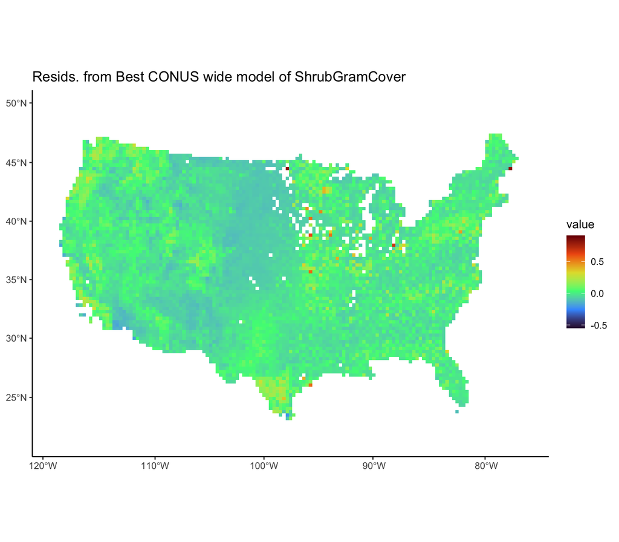

```r
pred_glm1 <- pred_glm1 %>%
  mutate(resid = .[[response]] - .[[paste0(response,"_pred")]])

# rasterize
# get reference raster
test_rast <-  rast("../../../data/dayMet/rawMonthlyData/orders/70e0da02b9d2d6e8faa8c97d211f3546/Daymet_Monthly_V4R1/data/daymet_v4_prcp_monttl_na_1980.tif") %>%
  terra::aggregate(fact = 32, fun = "mean")

# rasterize data
plotResid_rast <- pred_glm1 %>%
         drop_na(resid) %>%
  #slice_sample(n = 5e4) %>%
  terra::vect(geom = c("Lon", "Lat")) %>%
  terra::set.crs(crs(test_rast)) %>%
  terra::rasterize(y = test_rast,
                   field = "resid",
                   fun = mean) %>%
  terra::crop(ext(-2000000, 2500000, -2000000, 1200000))
# plot
ggplot() +
  geom_spatraster(data = plotResid_rast) +
  ggtitle(paste0("Resids. from Best CONUS wide model of ",s)) +
  scale_fill_viridis_c(option = "turbo", limits = c(-.55, .91), na.value = "white")
```

```r
# terra::plot(plotResid_rast, main = paste0("Resids. from Best CONUS wide model of ",s), clip = TRUE,
#             plg = list(title = "resid."),
#             col = map.pal("curvature"))
```

If applicable, residual plots of region-level models

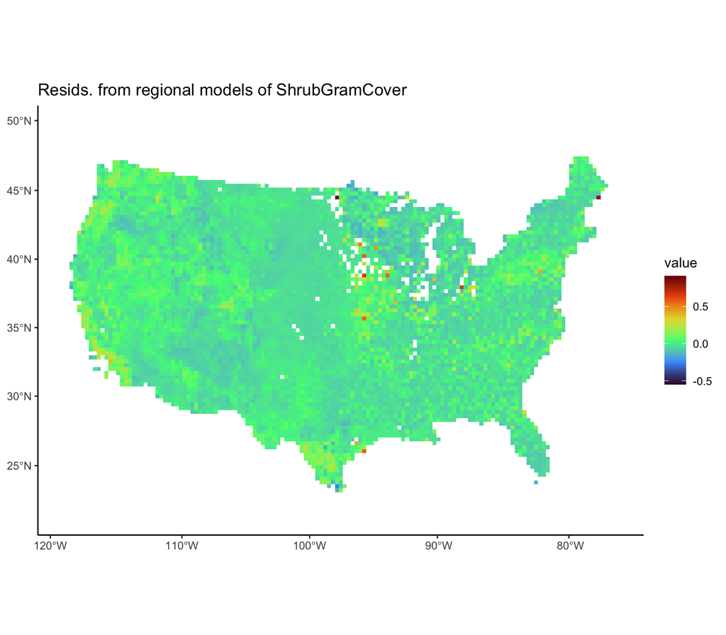

```r
if (byRegion == TRUE){
pred_glm1_ALL <- pred_glm1_ALL %>%
  mutate(resid = .[[response]] - .[[paste0(response,"_pred")]])

# rasterize

# rasterize data
plotResid_rast_ALL <- pred_glm1_ALL %>%
         drop_na(resid) %>%
  #slice_sample(n = 5e4) %>%
  terra::vect(geom = c("Lon", "Lat")) %>%
  terra::set.crs(crs(test_rast)) %>%
  terra::rasterize(y = test_rast,
                   field = "resid",
                   fun = mean) %>%
  terra::crop(ext(-2000000, 2500000, -2000000, 1200000))
# plot
ggplot() +
  geom_spatraster(data = plotResid_rast_ALL) +
  ggtitle(paste0("Resids. from regional models of ",s)) +
  scale_fill_viridis_c(option = "turbo", limits = c(-.55, .91), na.value = "white")
}
```

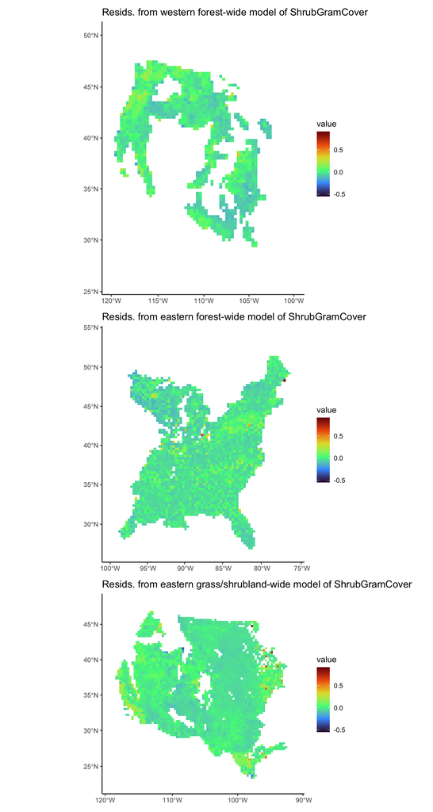

```r
if (byRegion == TRUE){
## for western forests
  pred_glm1_WF <- pred_glm1_WF %>%
  mutate(resid = .[[response]] - .[[paste0(response,"_pred")]])

# rasterize

# rasterize data
plotResid_rast_WF <- pred_glm1_WF %>%
         drop_na(resid) %>%
  #slice_sample(n = 5e4) %>%
  terra::vect(geom = c("Lon", "Lat")) %>%
  terra::set.crs(crs(test_rast)) %>%
  terra::rasterize(y = test_rast,
                   field = "resid",
                   fun = mean) %>%
  terra::crop(ext(-2000000, 0, -1500000, 1200000))
westForestRast <- ggplot() +
  geom_spatraster(data = plotResid_rast_WF) +
  ggtitle(paste0("Resids. from western forest-wide model of ",s)) +
  scale_fill_viridis_c(option = "turbo", limits = c(-.55, .91), na.value = "white")

## for eastern forests
  pred_glm1_EF <- pred_glm1_EF %>%
  mutate(resid = .[[response]] - .[[paste0(response,"_pred")]])

# rasterize data
plotResid_rast_EF <- pred_glm1_EF %>%
         drop_na(resid) %>%
  #slice_sample(n = 5e4) %>%
  terra::vect(geom = c("Lon", "Lat")) %>%
  terra::set.crs(crs(test_rast)) %>%
  terra::rasterize(y = test_rast,
                   field = "resid",
                   fun = mean) %>%
  terra::crop(ext(0, 2500000, -1700000, 1200000))

EastForestRast <- ggplot() +
  geom_spatraster(data = plotResid_rast_EF) +
  ggtitle(paste0("Resids. from eastern forest-wide model of ",s)) +
  scale_fill_viridis_c(option = "turbo", limits = c(-.55, .91), na.value = "white")

## for shrub/grassland
  pred_glm1_G <- pred_glm1_G %>%
  mutate(resid = .[[response]] - .[[paste0(response,"_pred")]])

# rasterize data
plotResid_rast_G <- pred_glm1_G %>%
         drop_na(resid) %>%
  #slice_sample(n = 5e4) %>%
  terra::vect(geom = c("Lon", "Lat")) %>%
  terra::set.crs(crs(test_rast)) %>%
  terra::rasterize(y = test_rast,
                   field = "resid",
                   fun = mean) %>%
  terra::crop(ext(-2000000, 900000, -1900000, 1000000))
grassRast <- ggplot() +
  geom_spatraster(data = plotResid_rast_G) +
  ggtitle(paste0("Resids. from eastern grass/shrubland-wide model of ",s)) +
  scale_fill_viridis_c(option = "turbo", limits = c(-.55, .91), na.value = "white")

westForestRast / EastForestRast / grassRast
}
```

### Deciles

Binning predictor variables into deciles (actually percentiles) and looking at the mean predicted probability for each percentile. The use of the word deciles is just a legacy thing (they started out being actual deciles)

```r
var_prop_pred <- paste0(response, "_pred")
response_vars <- c(response, var_prop_pred)

pred_glm1_deciles <- predvars2deciles(pred_glm1,
                                      response_vars = response_vars,
                                      pred_vars = pred_vars)

if (byRegion == TRUE) {
  ## western forests
  pred_glm1_deciles_WF <- predvars2deciles(pred_glm1_WF,
                                      response_vars = response_vars,
                                      pred_vars = pred_vars) %>%
    mutate(newRegion = "westernForest")

    ## eastern forests
  pred_glm1_deciles_EF <- predvars2deciles(pred_glm1_EF,
                                      response_vars = response_vars,
                                      pred_vars = pred_vars) %>%
    mutate(newRegion = "easternForest")

    ## grass/shrub
  pred_glm1_deciles_G <- predvars2deciles(pred_glm1_G,
                                      response_vars = response_vars,
                                      pred_vars = pred_vars) %>%
    mutate(newRegion = "grassShrub")

  ## put together for later figures
  pred_glm1_deciles_ALL <- predvars2deciles(pred_glm1_ALL,
                                      response_vars = response_vars,
                                      pred_vars = pred_vars)
}
```

Publication quality quantile plot

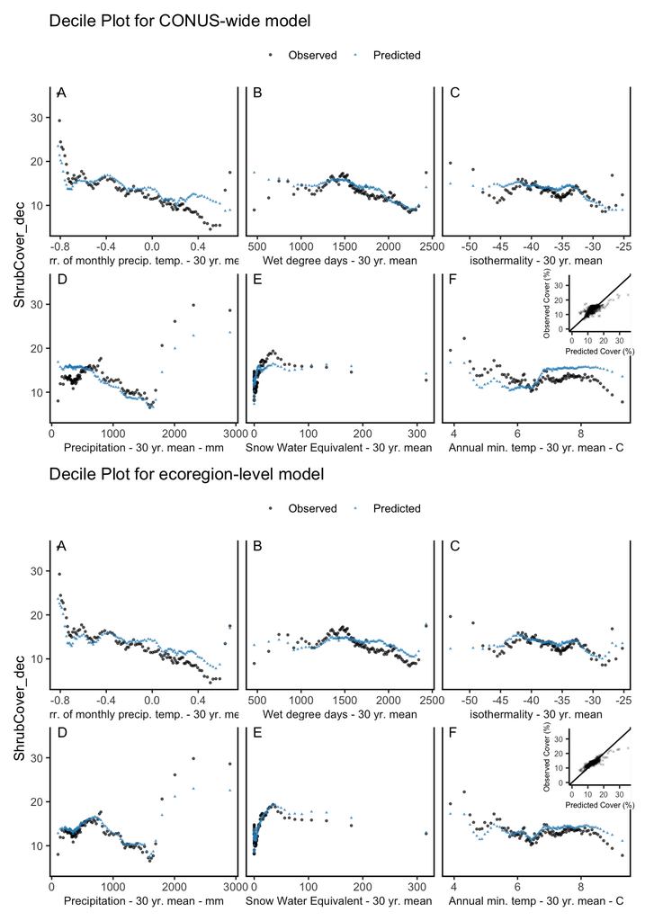

```r
# publication quality version
g3 <- decile_dotplot_pq(pred_glm1_deciles, response = response) + ggtitle("Decile Plot for CONUS-wide model")

if(!hmod) {
# obs/pred inset
g4 <- add_dotplot_inset(g3, pred_glm1_deciles)
} else {
  g4 <- g3
}
if (byRegion == FALSE){
  g4
}


if(save_figs) {
  png(paste0("figures/quantile_plots/quantile_plot_v5_CONUS_wideModel_", s,  ".png"),
     units = "in", res = 600, width = 5.5, height = 3.5 )
    print(g2)
  dev.off()
}
if (byRegion == TRUE) {

  # publication quality version
g <- decile_dotplot_pq(pred_glm1_deciles_ALL, response = response) + ggtitle("Decile Plot for ecoregion-level model")

if(!hmod) {
# obs/pred inset
g2 <- add_dotplot_inset(g, pred_glm1_deciles_ALL)
} else {
  g2 <- g
}

if(save_figs) {
  png(paste0("figures/quantile_plots/quantile_plot_v5_regionLevelModel", s,  ".png"),
     units = "in", res = 600, width = 5.5, height = 3.5 )
    print(g2)
  dev.off()
}


g4/g2
}
```

### Deciles Filtered

20th and 80th percentiles for each climate variable

```r
df <- pred_glm1[, pred_vars] #%>%
  #mutate(MAT = MAT - 273.15) # k to c
map(df, quantile, probs = c(0.2, 0.8), na.rm = TRUE)
```

```
## $swe_meanAnnAvg_30yr
##         20%         80%
##  0.03273187 16.84926538
##
## $tmean_meanAnnAvg_30yr
##      20%      80%
## 5.858387 7.805270
##
## $prcp_meanAnnTotal_30yr
##       20%       80%
##  324.6862 1259.2813
##
## $PrecipTempCorr_meanAnnAvg_30yr
##        20%        80%
## -0.5898152  0.2722877
##
## $isothermality_meanAnnAvg_30yr
##      20%      80%
## -41.3700 -33.0526
##
## $annWetDegDays_meanAnnAvg_30yr
##      20%      80%
## 1345.945 2034.911
```

Filtered ‘Decile’ plots of data. These plots show each vegetation variable, but only based on data that falls into the upper and lower two deciles of each climate variable.

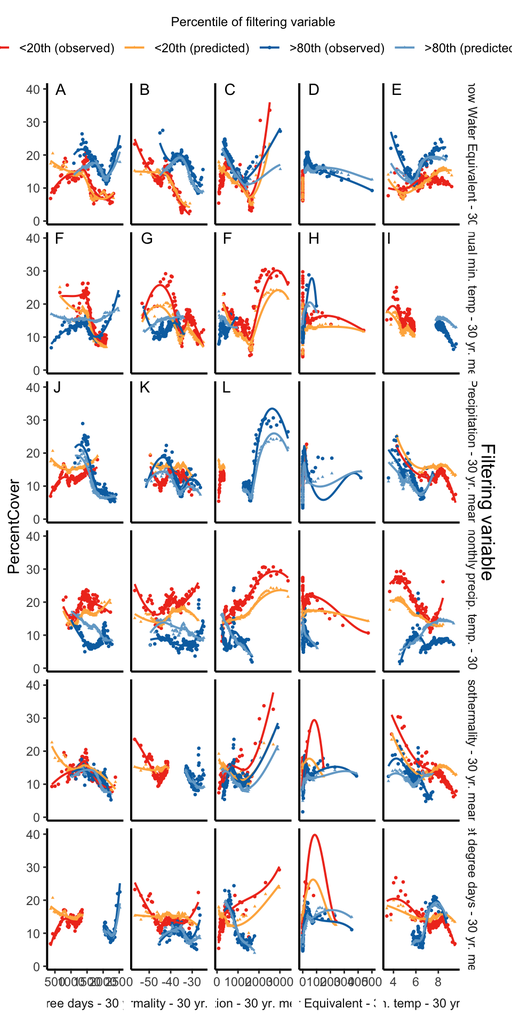

```r
clim_vars <- c("swe_meanAnnAvg_30yr", "tmean_meanAnnAvg_30yr", "prcp_meanAnnTotal_30yr", "precip_Seasonality_meanAnnAvg_30yr", "isothermality_meanAnnAvg_30yr", "annWetDegDays_meanAnnAvg_30yr")
pred_glm1_deciles_filt <- predvars2deciles( pred_glm1,
                         response_vars = response_vars,
                         pred_vars = pred_vars,
                         filter_var = TRUE,
                         filter_vars = pred_vars)

decile_dotplot_filtered_pq(pred_glm1_deciles_filt, xvars = clim_vars)
```

```r
#decile_dotplot_filtered_pq(pred_glm1_deciles_filt)
```

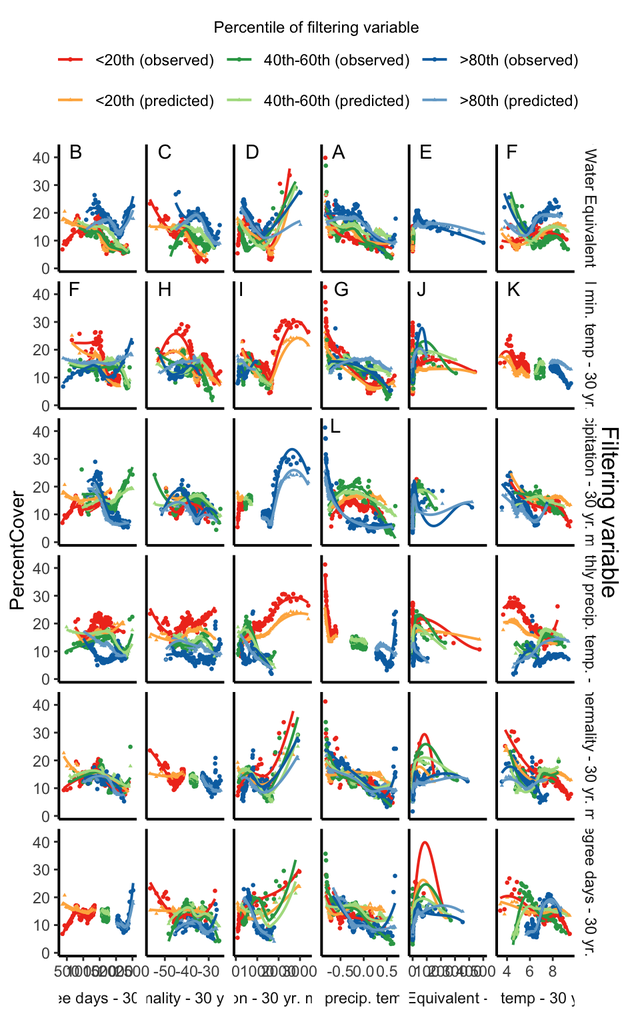

```r
pred_glm1_deciles_filt_mid <- predvars2deciles(pred_glm1,
                         response_vars = response_vars,
                         pred_vars = pred_vars,
                         filter_vars = pred_vars,
                         filter_var = TRUE,
                         add_mid = TRUE)

g <- decile_dotplot_filtered_pq(df = pred_glm1_deciles_filt_mid, xvars = pred_vars)
g
```

```r
if(save_figs) {x
jpeg(paste0("figures/quantile_plots/quantile_plot_filtered_mid_v1", s, ".jpeg"),
     units = "in", res = 600, width = 5.5, height = 6 )
  g
dev.off()
}
```

# Save output

```r
# glm models
mods2save <- butcher::butcher(mod_glmFinal) # removes some model components so the saved object isn't huge

mods2save$formula <- best_form
#mods2save$pred_vars_inter <- pred_vars_inter # so have interactions
n <- nrow(df_sample)
mods2save$data_rows <- n

if (byRegion == TRUE){
  mods2save_WF <- butcher::butcher(mod_glmFinal_WF) # removes some model components so the saved object isn't huge

mods2save_WF$formula <- best_form_WF
#mods2save$pred_vars_inter <- pred_vars_inter # so have interactions
mods2save_WF$data_rows <- nrow(wf_sample)

mods2save_EF <- butcher::butcher(mod_glmFinal_EF) # removes some model components so the saved object isn't huge

mods2save_EF$formula <- best_form_EF
#mods2save$pred_vars_inter <- pred_vars_inter # so have interactions
mods2save_EF$data_rows <- nrow(ef_sample)

  mods2save_G <- butcher::butcher(mod_glmFinal_G) # removes some model components so the saved object isn't huge

mods2save_G$formula <- best_form_G
#mods2save$pred_vars_inter <- pred_vars_inter # so have interactions
mods2save_G$data_rows <- nrow(g_sample)
}

if(!test_run) {
  saveRDS(mods2save,
        paste0("./models/glm_beta_model_CONUSwide_", s, "_n", n,
        #sample_group,
        ".RDS"))
  if (byRegion == TRUE) {
    ## western forests
     saveRDS(mods2save_WF,
        paste0("./models/glm_beta_model_WesternForests_", s, "_n", n,
        #sample_group,
        ".RDS"))
    ## eastern forests
     saveRDS(mods2save_EF,
        paste0("./models/glm_beta_model_EasternForests_", s, "_n", n,
        #sample_group,
        ".RDS"))
     ## grass/shrub
     saveRDS(mods2save_G,
        paste0("./models/glm_beta_model_GrassShrub_", s, "_n", n,
        #sample_group,
        ".RDS"))
  }
}
```

# session info

Hash of current commit (i.e. to ID the version of the code used)

```r
system("git rev-parse HEAD", intern=TRUE)
```

```
## [1] "4cabefa72252f87135d59263bd071d67b047b86e"
```